# Risk Factor Analysis

## Outcome Variable

**Outcome Variable:** whz

## Predictor Variables

**Intervention Variable:** mwtkg

**Adjustment Set:**

- arm
- W_mage
- W_fage
- meducyrs
- feducyrs
- single
- brthmon
- delta_W_mage
- delta_W_fage
- delta_meducyrs
- delta_feducyrs
- delta_single
- delta_brthmon

## Stratifying Variables

The analysis was stratified on these variable(s):

- agecat
- studyid
- country

## Data Summary

| agecat | studyid | country | mwtkg | n_cell | n |
| --- | --- | --- | --- | --- | --- |
| Birth | ki0047075b-MAL-ED | BANGLADESH | >=58 kg | 46 | 233 |
| Birth | ki0047075b-MAL-ED | BANGLADESH | <52 kg | 144 | 233 |
| Birth | ki0047075b-MAL-ED | BANGLADESH | [52-58) kg | 43 | 233 |
| Birth | ki0047075b-MAL-ED | BRAZIL | >=58 kg | 117 | 176 |
| Birth | ki0047075b-MAL-ED | BRAZIL | <52 kg | 31 | 176 |
| Birth | ki0047075b-MAL-ED | BRAZIL | [52-58) kg | 28 | 176 |
| Birth | ki0047075b-MAL-ED | INDIA | >=58 kg | 36 | 195 |
| Birth | ki0047075b-MAL-ED | INDIA | <52 kg | 121 | 195 |
| Birth | ki0047075b-MAL-ED | INDIA | [52-58) kg | 38 | 195 |
| Birth | ki0047075b-MAL-ED | NEPAL | >=58 kg | 56 | 167 |
| Birth | ki0047075b-MAL-ED | NEPAL | <52 kg | 48 | 167 |
| Birth | ki0047075b-MAL-ED | NEPAL | [52-58) kg | 63 | 167 |
| Birth | ki0047075b-MAL-ED | PERU | >=58 kg | 97 | 269 |
| Birth | ki0047075b-MAL-ED | PERU | <52 kg | 104 | 269 |
| Birth | ki0047075b-MAL-ED | PERU | [52-58) kg | 68 | 269 |
| Birth | ki0047075b-MAL-ED | SOUTH AFRICA | >=58 kg | 165 | 226 |
| Birth | ki0047075b-MAL-ED | SOUTH AFRICA | <52 kg | 23 | 226 |
| Birth | ki0047075b-MAL-ED | SOUTH AFRICA | [52-58) kg | 38 | 226 |
| Birth | ki0047075b-MAL-ED | TANZANIA, UNITED REPUBLIC OF | >=58 kg | 51 | 116 |
| Birth | ki0047075b-MAL-ED | TANZANIA, UNITED REPUBLIC OF | <52 kg | 37 | 116 |
| Birth | ki0047075b-MAL-ED | TANZANIA, UNITED REPUBLIC OF | [52-58) kg | 28 | 116 |
| Birth | ki1000304b-SAS-CompFeed | INDIA | >=58 kg | 12 | 162 |
| Birth | ki1000304b-SAS-CompFeed | INDIA | <52 kg | 124 | 162 |
| Birth | ki1000304b-SAS-CompFeed | INDIA | [52-58) kg | 26 | 162 |
| Birth | ki1017093-NIH-Birth | BANGLADESH | >=58 kg | 2 | 28 |
| Birth | ki1017093-NIH-Birth | BANGLADESH | <52 kg | 23 | 28 |
| Birth | ki1017093-NIH-Birth | BANGLADESH | [52-58) kg | 3 | 28 |
| Birth | ki1017093c-NIH-Crypto | BANGLADESH | >=58 kg | 4 | 23 |
| Birth | ki1017093c-NIH-Crypto | BANGLADESH | <52 kg | 17 | 23 |
| Birth | ki1017093c-NIH-Crypto | BANGLADESH | [52-58) kg | 2 | 23 |

[output cut: 93 more lines]

The following strata were considered:

- agecat: 24 months, studyid: ki0047075b-MAL-ED, country: BANGLADESH
- agecat: 24 months, studyid: ki0047075b-MAL-ED, country: BRAZIL
- agecat: 24 months, studyid: ki0047075b-MAL-ED, country: INDIA
- agecat: 24 months, studyid: ki0047075b-MAL-ED, country: NEPAL
- agecat: 24 months, studyid: ki0047075b-MAL-ED, country: PERU
- agecat: 24 months, studyid: ki0047075b-MAL-ED, country: SOUTH AFRICA
- agecat: 24 months, studyid: ki0047075b-MAL-ED, country: TANZANIA, UNITED REPUBLIC OF
- agecat: 24 months, studyid: ki1017093-NIH-Birth, country: BANGLADESH
- agecat: 24 months, studyid: ki1017093b-PROVIDE, country: BANGLADESH
- agecat: 24 months, studyid: ki1017093c-NIH-Crypto, country: BANGLADESH
- agecat: 24 months, studyid: ki1066203-TanzaniaChild2, country: TANZANIA, UNITED REPUBLIC OF
- agecat: 24 months, studyid: ki1119695-PROBIT, country: BELARUS
- agecat: 24 months, studyid: ki1126311-ZVITAMBO, country: ZIMBABWE
- agecat: 24 months, studyid: ki1148112-LCNI-5, country: MALAWI
- agecat: 6 months, studyid: ki0047075b-MAL-ED, country: BANGLADESH
- agecat: 6 months, studyid: ki0047075b-MAL-ED, country: BRAZIL
- agecat: 6 months, studyid: ki0047075b-MAL-ED, country: INDIA
- agecat: 6 months, studyid: ki0047075b-MAL-ED, country: NEPAL
- agecat: 6 months, studyid: ki0047075b-MAL-ED, country: PERU
- agecat: 6 months, studyid: ki0047075b-MAL-ED, country: SOUTH AFRICA
- agecat: 6 months, studyid: ki0047075b-MAL-ED, country: TANZANIA, UNITED REPUBLIC OF
- agecat: 6 months, studyid: ki1000304b-SAS-CompFeed, country: INDIA
- agecat: 6 months, studyid: ki1017093-NIH-Birth, country: BANGLADESH
- agecat: 6 months, studyid: ki1017093b-PROVIDE, country: BANGLADESH
- agecat: 6 months, studyid: ki1017093c-NIH-Crypto, country: BANGLADESH
- agecat: 6 months, studyid: ki1066203-TanzaniaChild2, country: TANZANIA, UNITED REPUBLIC OF
- agecat: 6 months, studyid: ki1119695-PROBIT, country: BELARUS
- agecat: 6 months, studyid: ki1126311-ZVITAMBO, country: ZIMBABWE
- agecat: 6 months, studyid: ki1148112-LCNI-5, country: MALAWI
- agecat: Birth, studyid: ki0047075b-MAL-ED, country: BANGLADESH
- agecat: Birth, studyid: ki0047075b-MAL-ED, country: BRAZIL
- agecat: Birth, studyid: ki0047075b-MAL-ED, country: INDIA
- agecat: Birth, studyid: ki0047075b-MAL-ED, country: NEPAL
- agecat: Birth, studyid: ki0047075b-MAL-ED, country: PERU
- agecat: Birth, studyid: ki0047075b-MAL-ED, country: SOUTH AFRICA
- agecat: Birth, studyid: ki0047075b-MAL-ED, country: TANZANIA, UNITED REPUBLIC OF
- agecat: Birth, studyid: ki1000304b-SAS-CompFeed, country: INDIA
- agecat: Birth, studyid: ki1017093-NIH-Birth, country: BANGLADESH
- agecat: Birth, studyid: ki1017093c-NIH-Crypto, country: BANGLADESH
- agecat: Birth, studyid: ki1119695-PROBIT, country: BELARUS
- agecat: Birth, studyid: ki1126311-ZVITAMBO, country: ZIMBABWE

### Dropped Strata

Some strata were dropped due to rare outcomes:

- agecat: Birth, studyid: ki1017093-NIH-Birth, country: BANGLADESH
- agecat: Birth, studyid: ki1017093c-NIH-Crypto, country: BANGLADESH
- agecat: 24 months, studyid: ki1066203-TanzaniaChild2, country: TANZANIA, UNITED REPUBLIC OF

## Methods Detail

We’re interested in the causal parameters $E[Y_a]$ for all values of $a \in \mathcal{A}$. These parameters represent the mean outcome if, possibly contrary to fact, we intervened to set all units to have $A=a$. Under the randomization and positivity assumptions, these are identified by the statistical parameters $\psi_a=E_W[E_{Y|A,W}(Y|A=a,W)]$. In addition, we’re interested in the mean of $Y$, $E[Y]$ under no intervention (the observed mean). We will estimate these parameters by using SuperLearner to fit the relevant likelihood factors – $E_{Y|A,W}(Y|A=a,W)$ and $p(A=a|W)$, and then updating our likelihood fit using a joint TMLE.

For unadjusted analyses ($W=\{\}$), initial likelihoods were estimated using Lrnr_glm to estimate the simple $E(Y|A)$ and Lrnr_mean to estimate $p(A)$. For adjusted analyses, a small library containing Lrnr_glmnet, Lrnr_xgboost, and Lrnr_mean was used.

Having estimated these parameters, we will then use the delta method to estimate relative risks and attributable risks relative to a prespecified baseline level of $A$.

# Results Detail

## Results Plots

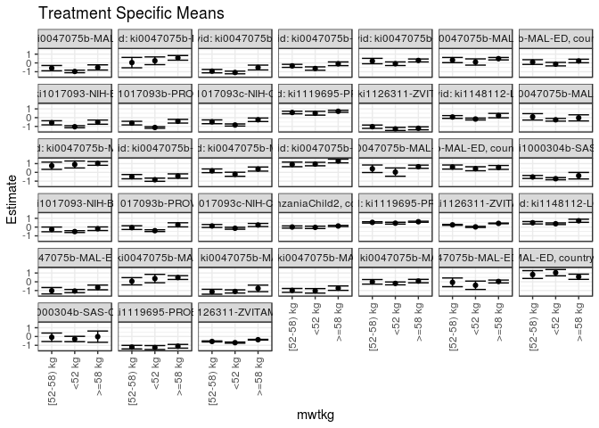

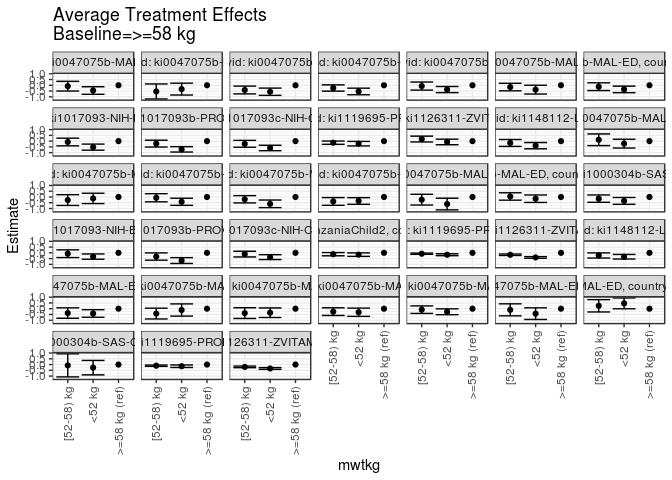

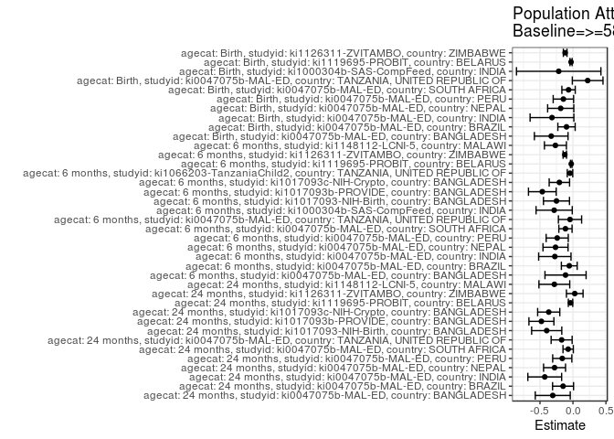

## Results Table

### Parameter: TSM

| agecat | studyid | country | intervention_level | baseline_level | estimate | ci_lower | ci_upper |
| --- | --- | --- | --- | --- | --- | --- | --- |
| Birth | ki0047075b-MAL-ED | BANGLADESH | >=58 kg | NA | -0.6427969 | -0.9123273 | -0.3732664 |
| Birth | ki0047075b-MAL-ED | BANGLADESH | <52 kg | NA | -1.0571692 | -1.2396410 | -0.8746975 |
| Birth | ki0047075b-MAL-ED | BANGLADESH | [52-58) kg | NA | -1.0204929 | -1.3845803 | -0.6564055 |
| Birth | ki0047075b-MAL-ED | BRAZIL | >=58 kg | NA | 0.4808595 | 0.2632329 | 0.6984861 |
| Birth | ki0047075b-MAL-ED | BRAZIL | <52 kg | NA | 0.3672660 | -0.1123013 | 0.8468334 |
| Birth | ki0047075b-MAL-ED | BRAZIL | [52-58) kg | NA | 0.0583147 | -0.3540375 | 0.4706669 |
| Birth | ki0047075b-MAL-ED | INDIA | >=58 kg | NA | -0.7519432 | -1.1245466 | -0.3793398 |
| Birth | ki0047075b-MAL-ED | INDIA | <52 kg | NA | -1.1014491 | -1.2838437 | -0.9190546 |
| Birth | ki0047075b-MAL-ED | INDIA | [52-58) kg | NA | -1.1341065 | -1.4140651 | -0.8541480 |
| Birth | ki0047075b-MAL-ED | NEPAL | >=58 kg | NA | -0.7272241 | -0.9785705 | -0.4758777 |
| Birth | ki0047075b-MAL-ED | NEPAL | <52 kg | NA | -1.0329796 | -1.2891532 | -0.7768061 |
| Birth | ki0047075b-MAL-ED | NEPAL | [52-58) kg | NA | -0.9823672 | -1.2006937 | -0.7640408 |
| Birth | ki0047075b-MAL-ED | PERU | >=58 kg | NA | 0.0787965 | -0.1143230 | 0.2719160 |
| Birth | ki0047075b-MAL-ED | PERU | <52 kg | NA | -0.1861201 | -0.3491700 | -0.0230702 |
| Birth | ki0047075b-MAL-ED | PERU | [52-58) kg | NA | -0.0056744 | -0.2669614 | 0.2556126 |
| Birth | ki0047075b-MAL-ED | SOUTH AFRICA | >=58 kg | NA | 0.0320898 | -0.1292647 | 0.1934442 |
| Birth | ki0047075b-MAL-ED | SOUTH AFRICA | <52 kg | NA | -0.3967822 | -0.8753013 | 0.0817369 |
| Birth | ki0047075b-MAL-ED | SOUTH AFRICA | [52-58) kg | NA | -0.0650151 | -0.5601877 | 0.4301575 |
| Birth | ki0047075b-MAL-ED | TANZANIA, UNITED REPUBLIC OF | >=58 kg | NA | 0.5720576 | 0.2742967 | 0.8698185 |
| Birth | ki0047075b-MAL-ED | TANZANIA, UNITED REPUBLIC OF | <52 kg | NA | 1.0351090 | 0.6781855 | 1.3920325 |
| Birth | ki0047075b-MAL-ED | TANZANIA, UNITED REPUBLIC OF | [52-58) kg | NA | 0.8236787 | 0.3796881 | 1.2676693 |
| Birth | ki1000304b-SAS-CompFeed | INDIA | >=58 kg | NA | -0.0191998 | -0.6621877 | 0.6237880 |
| Birth | ki1000304b-SAS-CompFeed | INDIA | <52 kg | NA | -0.2869716 | -0.5919010 | 0.0179579 |
| Birth | ki1000304b-SAS-CompFeed | INDIA | [52-58) kg | NA | -0.0892779 | -0.5745952 | 0.3960394 |
| Birth | ki1119695-PROBIT | BELARUS | >=58 kg | NA | -1.1153932 | -1.3287973 | -0.9019892 |
| Birth | ki1119695-PROBIT | BELARUS | <52 kg | NA | -1.2596933 | -1.4858918 | -1.0334949 |
| Birth | ki1119695-PROBIT | BELARUS | [52-58) kg | NA | -1.2146553 | -1.4177697 | -1.0115408 |
| Birth | ki1126311-ZVITAMBO | ZIMBABWE | >=58 kg | NA | -0.3638529 | -0.4043330 | -0.3233729 |
| Birth | ki1126311-ZVITAMBO | ZIMBABWE | <52 kg | NA | -0.7035193 | -0.7666588 | -0.6403798 |
| Birth | ki1126311-ZVITAMBO | ZIMBABWE | [52-58) kg | NA | -0.5670910 | -0.6238228 | -0.5103593 |

[output cut: 84 more lines]

### Parameter: E(Y)

| agecat | studyid | country | intervention_level | baseline_level | estimate | ci_lower | ci_upper |
| --- | --- | --- | --- | --- | --- | --- | --- |
| Birth | ki0047075b-MAL-ED | BANGLADESH | NA | NA | -0.9724464 | -1.1091046 | -0.8357881 |
| Birth | ki0047075b-MAL-ED | BRAZIL | NA | NA | 0.3832386 | 0.2044597 | 0.5620175 |
| Birth | ki0047075b-MAL-ED | INDIA | NA | NA | -1.0698974 | -1.2115847 | -0.9282102 |
| Birth | ki0047075b-MAL-ED | NEPAL | NA | NA | -0.9126946 | -1.0520834 | -0.7733058 |
| Birth | ki0047075b-MAL-ED | PERU | NA | NA | -0.0660967 | -0.1789362 | 0.0467429 |
| Birth | ki0047075b-MAL-ED | SOUTH AFRICA | NA | NA | -0.0346018 | -0.1831486 | 0.1139451 |
| Birth | ki0047075b-MAL-ED | TANZANIA, UNITED REPUBLIC OF | NA | NA | 0.7950000 | 0.5947353 | 0.9952647 |
| Birth | ki1000304b-SAS-CompFeed | INDIA | NA | NA | -0.2353086 | -0.4984656 | 0.0278483 |
| Birth | ki1119695-PROBIT | BELARUS | NA | NA | -1.1441825 | -1.3547365 | -0.9336286 |
| Birth | ki1126311-ZVITAMBO | ZIMBABWE | NA | NA | -0.4819806 | -0.5108811 | -0.4530800 |
| 6 months | ki0047075b-MAL-ED | BANGLADESH | NA | NA | -0.1397960 | -0.2688682 | -0.0107238 |
| 6 months | ki0047075b-MAL-ED | BRAZIL | NA | NA | 0.9644952 | 0.7999744 | 1.1290160 |
| 6 months | ki0047075b-MAL-ED | INDIA | NA | NA | -0.6987943 | -0.8241325 | -0.5734561 |
| 6 months | ki0047075b-MAL-ED | NEPAL | NA | NA | 0.1110452 | -0.0202712 | 0.2423616 |
| 6 months | ki0047075b-MAL-ED | PERU | NA | NA | 1.0563787 | 0.9342938 | 1.1784635 |
| 6 months | ki0047075b-MAL-ED | SOUTH AFRICA | NA | NA | 0.5290428 | 0.3750394 | 0.6830463 |
| 6 months | ki0047075b-MAL-ED | TANZANIA, UNITED REPUBLIC OF | NA | NA | 0.5170513 | 0.3872178 | 0.6468847 |
| 6 months | ki1000304b-SAS-CompFeed | INDIA | NA | NA | -0.6674586 | -0.8042294 | -0.5306877 |
| 6 months | ki1017093-NIH-Birth | BANGLADESH | NA | NA | -0.4389101 | -0.5279432 | -0.3498771 |
| 6 months | ki1017093b-PROVIDE | BANGLADESH | NA | NA | -0.2079891 | -0.2925599 | -0.1234183 |
| 6 months | ki1017093c-NIH-Crypto | BANGLADESH | NA | NA | 0.0297622 | -0.0491685 | 0.1086930 |
| 6 months | ki1066203-TanzaniaChild2 | TANZANIA, UNITED REPUBLIC OF | NA | NA | 0.0780261 | 0.0247830 | 0.1312691 |
| 6 months | ki1119695-PROBIT | BELARUS | NA | NA | 0.5834072 | 0.5254491 | 0.6413653 |
| 6 months | ki1126311-ZVITAMBO | ZIMBABWE | NA | NA | 0.2953392 | 0.2687669 | 0.3219114 |
| 6 months | ki1148112-LCNI-5 | MALAWI | NA | NA | 0.4518399 | 0.3806212 | 0.5230586 |
| 24 months | ki0047075b-MAL-ED | BANGLADESH | NA | NA | -0.8208255 | -0.9429246 | -0.6987264 |
| 24 months | ki0047075b-MAL-ED | BRAZIL | NA | NA | 0.4282738 | 0.2252365 | 0.6313111 |
| 24 months | ki0047075b-MAL-ED | INDIA | NA | NA | -0.9525664 | -1.0684455 | -0.8366872 |
| 24 months | ki0047075b-MAL-ED | NEPAL | NA | NA | -0.3764474 | -0.4898516 | -0.2630431 |
| 24 months | ki0047075b-MAL-ED | PERU | NA | NA | 0.1199005 | -0.0000331 | 0.2398341 |
| 24 months | ki0047075b-MAL-ED | SOUTH AFRICA | NA | NA | 0.4096154 | 0.2902946 | 0.5289362 |
| 24 months | ki0047075b-MAL-ED | TANZANIA, UNITED REPUBLIC OF | NA | NA | 0.0500935 | -0.0748234 | 0.1750103 |
| 24 months | ki1017093-NIH-Birth | BANGLADESH | NA | NA | -0.9115790 | -1.0095022 | -0.8136559 |
| 24 months | ki1017093b-PROVIDE | BANGLADESH | NA | NA | -0.8864991 | -0.9695215 | -0.8034768 |
| 24 months | ki1017093c-NIH-Crypto | BANGLADESH | NA | NA | -0.6103502 | -0.7050157 | -0.5156847 |
| 24 months | ki1119695-PROBIT | BELARUS | NA | NA | 0.6877387 | 0.5737746 | 0.8017027 |
| 24 months | ki1126311-ZVITAMBO | ZIMBABWE | NA | NA | -1.1865133 | -1.2873598 | -1.0856668 |
| 24 months | ki1148112-LCNI-5 | MALAWI | NA | NA | -0.0467082 | -0.1287046 | 0.0352882 |

### Parameter: ATE

| agecat | studyid | country | intervention_level | baseline_level | estimate | ci_lower | ci_upper |
| --- | --- | --- | --- | --- | --- | --- | --- |
| Birth | ki0047075b-MAL-ED | BANGLADESH | >=58 kg | >=58 kg | 0.0000000 | 0.0000000 | 0.0000000 |
| Birth | ki0047075b-MAL-ED | BANGLADESH | <52 kg | >=58 kg | -0.4143724 | -0.7404451 | -0.0882997 |
| Birth | ki0047075b-MAL-ED | BANGLADESH | [52-58) kg | >=58 kg | -0.3776960 | -0.8314219 | 0.0760298 |
| Birth | ki0047075b-MAL-ED | BRAZIL | >=58 kg | >=58 kg | 0.0000000 | 0.0000000 | 0.0000000 |
| Birth | ki0047075b-MAL-ED | BRAZIL | <52 kg | >=58 kg | -0.1135934 | -0.6437652 | 0.4165783 |
| Birth | ki0047075b-MAL-ED | BRAZIL | [52-58) kg | >=58 kg | -0.4225448 | -0.8918479 | 0.0467583 |
| Birth | ki0047075b-MAL-ED | INDIA | >=58 kg | >=58 kg | 0.0000000 | 0.0000000 | 0.0000000 |
| Birth | ki0047075b-MAL-ED | INDIA | <52 kg | >=58 kg | -0.3495059 | -0.7648415 | 0.0658297 |
| Birth | ki0047075b-MAL-ED | INDIA | [52-58) kg | >=58 kg | -0.3821633 | -0.8479175 | 0.0835909 |
| Birth | ki0047075b-MAL-ED | NEPAL | >=58 kg | >=58 kg | 0.0000000 | 0.0000000 | 0.0000000 |
| Birth | ki0047075b-MAL-ED | NEPAL | <52 kg | >=58 kg | -0.3057555 | -0.6646149 | 0.0531039 |
| Birth | ki0047075b-MAL-ED | NEPAL | [52-58) kg | >=58 kg | -0.2551431 | -0.5885922 | 0.0783060 |
| Birth | ki0047075b-MAL-ED | PERU | >=58 kg | >=58 kg | 0.0000000 | 0.0000000 | 0.0000000 |
| Birth | ki0047075b-MAL-ED | PERU | <52 kg | >=58 kg | -0.2649166 | -0.5193474 | -0.0104858 |
| Birth | ki0047075b-MAL-ED | PERU | [52-58) kg | >=58 kg | -0.0844709 | -0.4110660 | 0.2421241 |
| Birth | ki0047075b-MAL-ED | SOUTH AFRICA | >=58 kg | >=58 kg | 0.0000000 | 0.0000000 | 0.0000000 |
| Birth | ki0047075b-MAL-ED | SOUTH AFRICA | <52 kg | >=58 kg | -0.4288720 | -0.9340989 | 0.0763550 |
| Birth | ki0047075b-MAL-ED | SOUTH AFRICA | [52-58) kg | >=58 kg | -0.0971049 | -0.6176858 | 0.4234760 |
| Birth | ki0047075b-MAL-ED | TANZANIA, UNITED REPUBLIC OF | >=58 kg | >=58 kg | 0.0000000 | 0.0000000 | 0.0000000 |
| Birth | ki0047075b-MAL-ED | TANZANIA, UNITED REPUBLIC OF | <52 kg | >=58 kg | 0.4630514 | -0.0044271 | 0.9305299 |
| Birth | ki0047075b-MAL-ED | TANZANIA, UNITED REPUBLIC OF | [52-58) kg | >=58 kg | 0.2516211 | -0.2840933 | 0.7873354 |
| Birth | ki1000304b-SAS-CompFeed | INDIA | >=58 kg | >=58 kg | 0.0000000 | 0.0000000 | 0.0000000 |
| Birth | ki1000304b-SAS-CompFeed | INDIA | <52 kg | >=58 kg | -0.2677717 | -0.8953010 | 0.3597575 |
| Birth | ki1000304b-SAS-CompFeed | INDIA | [52-58) kg | >=58 kg | -0.0700781 | -1.0721567 | 0.9320005 |
| Birth | ki1119695-PROBIT | BELARUS | >=58 kg | >=58 kg | 0.0000000 | 0.0000000 | 0.0000000 |
| Birth | ki1119695-PROBIT | BELARUS | <52 kg | >=58 kg | -0.1443001 | -0.2525067 | -0.0360935 |
| Birth | ki1119695-PROBIT | BELARUS | [52-58) kg | >=58 kg | -0.0992621 | -0.1586503 | -0.0398738 |
| Birth | ki1126311-ZVITAMBO | ZIMBABWE | >=58 kg | >=58 kg | 0.0000000 | 0.0000000 | 0.0000000 |
| Birth | ki1126311-ZVITAMBO | ZIMBABWE | <52 kg | >=58 kg | -0.3396664 | -0.4147037 | -0.2646290 |
| Birth | ki1126311-ZVITAMBO | ZIMBABWE | [52-58) kg | >=58 kg | -0.2032381 | -0.2729165 | -0.1335597 |

[output cut: 84 more lines]

### Parameter: PAR

| agecat | studyid | country | intervention_level | baseline_level | estimate | ci_lower | ci_upper |
| --- | --- | --- | --- | --- | --- | --- | --- |
| Birth | ki0047075b-MAL-ED | BANGLADESH | >=58 kg | NA | -0.3296495 | -0.5847126 | -0.0745864 |
| Birth | ki0047075b-MAL-ED | BRAZIL | >=58 kg | NA | -0.0976208 | -0.2287961 | 0.0335544 |
| Birth | ki0047075b-MAL-ED | INDIA | >=58 kg | NA | -0.3179542 | -0.6498481 | 0.0139396 |
| Birth | ki0047075b-MAL-ED | NEPAL | >=58 kg | NA | -0.1854705 | -0.3838550 | 0.0129140 |
| Birth | ki0047075b-MAL-ED | PERU | >=58 kg | NA | -0.1448932 | -0.2997544 | 0.0099681 |
| Birth | ki0047075b-MAL-ED | SOUTH AFRICA | >=58 kg | NA | -0.0666915 | -0.1681061 | 0.0347231 |
| Birth | ki0047075b-MAL-ED | TANZANIA, UNITED REPUBLIC OF | >=58 kg | NA | 0.2229424 | -0.0097162 | 0.4556010 |
| Birth | ki1000304b-SAS-CompFeed | INDIA | >=58 kg | NA | -0.2161088 | -0.8562357 | 0.4240180 |
| Birth | ki1119695-PROBIT | BELARUS | >=58 kg | NA | -0.0287893 | -0.0449417 | -0.0126370 |
| Birth | ki1126311-ZVITAMBO | ZIMBABWE | >=58 kg | NA | -0.1181276 | -0.1457285 | -0.0905267 |
| 6 months | ki0047075b-MAL-ED | BANGLADESH | >=58 kg | NA | -0.1124584 | -0.4242625 | 0.1993457 |
| 6 months | ki0047075b-MAL-ED | BRAZIL | >=58 kg | NA | -0.0558383 | -0.1755048 | 0.0638282 |
| 6 months | ki0047075b-MAL-ED | INDIA | >=58 kg | NA | -0.2747442 | -0.5201370 | -0.0293513 |
| 6 months | ki0047075b-MAL-ED | NEPAL | >=58 kg | NA | -0.2644799 | -0.4544289 | -0.0745309 |
| 6 months | ki0047075b-MAL-ED | PERU | >=58 kg | NA | -0.2386703 | -0.4063202 | -0.0710205 |
| 6 months | ki0047075b-MAL-ED | SOUTH AFRICA | >=58 kg | NA | -0.1136923 | -0.2140388 | -0.0133459 |
| 6 months | ki0047075b-MAL-ED | TANZANIA, UNITED REPUBLIC OF | >=58 kg | NA | -0.0445364 | -0.2204559 | 0.1313831 |
| 6 months | ki1000304b-SAS-CompFeed | INDIA | >=58 kg | NA | -0.2850425 | -0.5594709 | -0.0106140 |
| 6 months | ki1017093-NIH-Birth | BANGLADESH | >=58 kg | NA | -0.2497959 | -0.4471007 | -0.0524912 |
| 6 months | ki1017093b-PROVIDE | BANGLADESH | >=58 kg | NA | -0.4643203 | -0.6743776 | -0.2542631 |
| 6 months | ki1017093c-NIH-Crypto | BANGLADESH | >=58 kg | NA | -0.2059085 | -0.3605606 | -0.0512563 |
| 6 months | ki1066203-TanzaniaChild2 | TANZANIA, UNITED REPUBLIC OF | >=58 kg | NA | -0.0447000 | -0.0861488 | -0.0032513 |
| 6 months | ki1119695-PROBIT | BELARUS | >=58 kg | NA | -0.0259973 | -0.0375465 | -0.0144481 |
| 6 months | ki1126311-ZVITAMBO | ZIMBABWE | >=58 kg | NA | -0.1235762 | -0.1495378 | -0.0976146 |
| 6 months | ki1148112-LCNI-5 | MALAWI | >=58 kg | NA | -0.2659150 | -0.4325752 | -0.0992549 |
| 24 months | ki0047075b-MAL-ED | BANGLADESH | >=58 kg | NA | -0.3062025 | -0.5713315 | -0.0410735 |
| 24 months | ki0047075b-MAL-ED | BRAZIL | >=58 kg | NA | -0.1498438 | -0.3090131 | 0.0093255 |
| 24 months | ki0047075b-MAL-ED | INDIA | >=58 kg | NA | -0.4276455 | -0.6838011 | -0.1714899 |
| 24 months | ki0047075b-MAL-ED | NEPAL | >=58 kg | NA | -0.2789798 | -0.4454725 | -0.1124871 |
| 24 months | ki0047075b-MAL-ED | PERU | >=58 kg | NA | -0.1619371 | -0.3071637 | -0.0167105 |
| 24 months | ki0047075b-MAL-ED | SOUTH AFRICA | >=58 kg | NA | -0.0726769 | -0.1510365 | 0.0056828 |
| 24 months | ki0047075b-MAL-ED | TANZANIA, UNITED REPUBLIC OF | >=58 kg | NA | -0.1715452 | -0.3307913 | -0.0122990 |
| 24 months | ki1017093-NIH-Birth | BANGLADESH | >=58 kg | NA | -0.3979071 | -0.6265190 | -0.1692952 |
| 24 months | ki1017093b-PROVIDE | BANGLADESH | >=58 kg | NA | -0.4781986 | -0.6675550 | -0.2888421 |
| 24 months | ki1017093c-NIH-Crypto | BANGLADESH | >=58 kg | NA | -0.3674076 | -0.5353431 | -0.1994721 |
| 24 months | ki1119695-PROBIT | BELARUS | >=58 kg | NA | -0.0365826 | -0.0699060 | -0.0032592 |
| 24 months | ki1126311-ZVITAMBO | ZIMBABWE | >=58 kg | NA | 0.0272182 | -0.0988738 | 0.1533101 |
| 24 months | ki1148112-LCNI-5 | MALAWI | >=58 kg | NA | -0.2821856 | -0.5157792 | -0.0485920 |